# Glioblastoma FFPE Tissues Dissociated Manually or using gentleMACS Dissociator, Multiplexed Samples, 4 Probe Barcodes (Next GEM)

- Show All Code
- Hide All Code
- View Source

Authors

Azzeddine ALILICHE

Anais HLUSZKO

Corentin OSTA

Published

November 4, 2026

```r
suppressPackageStartupMessages({
  library(Seurat)
  library(dplyr)
  library(ggplot2)
  library(SingleCellExperiment)
  library(scDblFinder)
  library(gprofiler2)
  library(scales)
})
```

We set the sample name and the seed to avoid random values

```r
sample.name<-"Brain_DV200"
species<-"Human"
```

```r
the.seed<-42
set.seed(the.seed)
```

Dataset from 10x Genomincs : Manual dissection

https://cf.10xgenomics.com/samples/cell-exp/7.1.0/4plex_human_lungcancer_glioblastoma_scFFPE_multiplex_Glioblastoma_Manual_BC3/4plex_human_lungcancer_glioblastoma_scFFPE_multiplex_Glioblastoma_Manual_BC3_count_sample_raw_feature_bc_matrix.tar.gz

```r
scmat<-Read10X("../data/raw_data/sample_raw_feature_bc_matrix")
```

```r
class(scmat)
```

```
[1] "dgCMatrix"
attr(,"package")
[1] "Matrix"
```

```r
head(scmat)
```

```
6 x 392837 sparse Matrix of class "dgCMatrix"
```

```
MIR1302-2HG . . . . . . . . . . . . . . . . . . . . . . . . . . . . . . . . . .
FAM138A     . . . . . . . . . . . . . . . . . . . . . . . . . . . . . . . . . .
OR4F5       . . . . . . . . . . . . . . . . . . . . . . . . . . . . . . . . . .
AL627309.1  . . . . . . . . . . . . . . . . . . . . . . . . . . . . . . . . . .
AL627309.3  . . . . . . . . . . . . . . . . . . . . . . . . . . . . . . . . . .
AL627309.2  . . . . . . . . . . . . . . . . . . . . . . . . . . . . . . . . . .

MIR1302-2HG ......
FAM138A     ......
OR4F5       ......
AL627309.1  ......
AL627309.3  ......
AL627309.2  ......

 .....suppression de 392803 colonnes in show(); maybe adjust options(max.print=, width=)
 ..............................
```

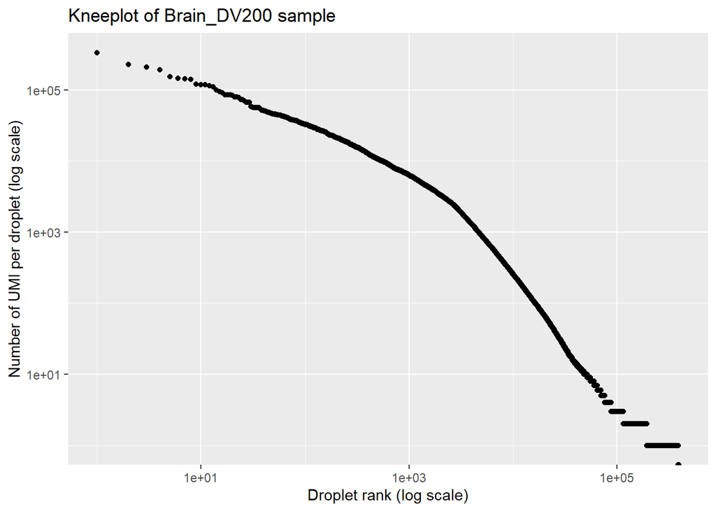

```r
nb_umi_by_barcode<- data.frame(
  nb_umi=Matrix::colSums(scmat),
  barcodes = colnames(scmat))


nb_umi_by_barcode<- nb_umi_by_barcode %>% arrange(desc(nb_umi)) %>% dplyr::mutate(num_barcode=seq.int(ncol(scmat)))

#knee plot
ggplot(nb_umi_by_barcode, aes(y = nb_umi, x = num_barcode)) +
  geom_point() + ggtitle(paste0("Kneeplot of ", sample.name, " sample")) +
  theme(legend.title = element_blank()) +
  scale_y_log10(name = "Number of UMI per droplet (log scale)") +
  scale_x_log10(name = "Droplet rank (log scale)") +
  expand_limits(x = 0, y = 0) +
  guides(colour = guide_legend(override.aes = list(linetype = c(0, 0), shape = c(16, 16))))
```

The knee-plot look perfect, we have a unique knee at approx 3000umi, next step is to create a seurat object.

Note : this is the *raw* matrix (all barcodes, including empty droplets), so the gene/UMI filters below also act as the empty-droplet filter. Using `sample_filtered_feature_bc_matrix` (Cell Ranger cell calling) or `DropletUtils::emptyDrops` would be more rigorous.

```r
sobj <- CreateSeuratObject(
  counts = scmat,
  min.cells = 5,
  min.features = 200,
  project = sample.name)
```

```r
#class of our Seurat Object
class(sobj)
```

```
[1] "Seurat"
attr(,"package")
[1] "SeuratObject"
```

```r
#barcodes names
head(sobj)
```

```
                            orig.ident nCount_RNA nFeature_RNA
AAACAAGCAAGCTATGAGTAGGCT-1 Brain_DV200        259          238
AAACAAGCACAATGGCAGTAGGCT-1 Brain_DV200       2911         1703
AAACAAGCACTAACAGAGTAGGCT-1 Brain_DV200        411          317
AAACAAGCATGGCTTTAGTAGGCT-1 Brain_DV200       3312         2285
AAACAAGCATTTGCTAAGTAGGCT-1 Brain_DV200       2630         1833
AAACCAATCATCAAGAAGTAGGCT-1 Brain_DV200        885          656
AAACCAATCATCCAGCAGTAGGCT-1 Brain_DV200       2175         1530
AAACCAATCGCGCATTAGTAGGCT-1 Brain_DV200        710          549
AAACCAATCTGCAACCAGTAGGCT-1 Brain_DV200       1910         1513
AAACCAATCTTGAGGGAGTAGGCT-1 Brain_DV200        279          246
```

```r
# number of barcodes
ncol(sobj)
```

```
[1] 10306
```

```r
# number of features
nrow(sobj)
```

```
[1] 18988
```

```r
# the object
sobj
```

```
An object of class Seurat
18988 features across 10306 samples within 1 assay
Active assay: RNA (18988 features, 0 variable features)
 1 layer present: counts
```

```r
rm(nb_umi_by_barcode, scmat)
gc()
```

```
           used  (Mb) gc trigger   (Mb)  max used  (Mb)
Ncells 11998128 640.8   19463582 1039.5  15890783 848.7
Vcells 43763039 333.9  132681792 1012.3 110471620 842.9
```

```r
sobj@meta.data[1:10,]
```

```
                            orig.ident nCount_RNA nFeature_RNA
AAACAAGCAAGCTATGAGTAGGCT-1 Brain_DV200        259          238
AAACAAGCACAATGGCAGTAGGCT-1 Brain_DV200       2911         1703
AAACAAGCACTAACAGAGTAGGCT-1 Brain_DV200        411          317
AAACAAGCATGGCTTTAGTAGGCT-1 Brain_DV200       3312         2285
AAACAAGCATTTGCTAAGTAGGCT-1 Brain_DV200       2630         1833
AAACCAATCATCAAGAAGTAGGCT-1 Brain_DV200        885          656
AAACCAATCATCCAGCAGTAGGCT-1 Brain_DV200       2175         1530
AAACCAATCGCGCATTAGTAGGCT-1 Brain_DV200        710          549
AAACCAATCTGCAACCAGTAGGCT-1 Brain_DV200       1910         1513
AAACCAATCTTGAGGGAGTAGGCT-1 Brain_DV200        279          246
```

```r
sobj@assays$RNA@layers$counts[1:10,1:4]
```

```
10 x 4 sparse Matrix of class "dgCMatrix"

 [1,] . . . .
 [2,] . . . .
 [3,] . 1 . .
 [4,] . . . .
 [5,] . . . .
 [6,] . . . .
 [7,] . . . .
 [8,] . . . .
 [9,] . . . .
[10,] . . . .
```

Now lets filter our object, remove undersequenced cells, debris, duplicates or multiplets.

```r
summary(sobj$nFeature_RNA)
```

```
   Min. 1st Qu.  Median    Mean 3rd Qu.    Max.
    200     326     628    1298    1672   14754
```

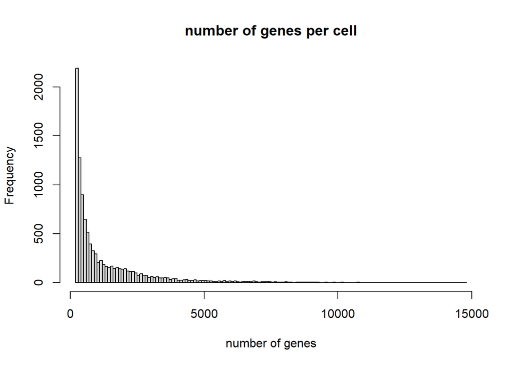

```r
#histogram
hist(sobj$nFeature_RNA,
     breaks = 200,
     xlab = "number of genes",
     main = "number of genes per cell"
)
```

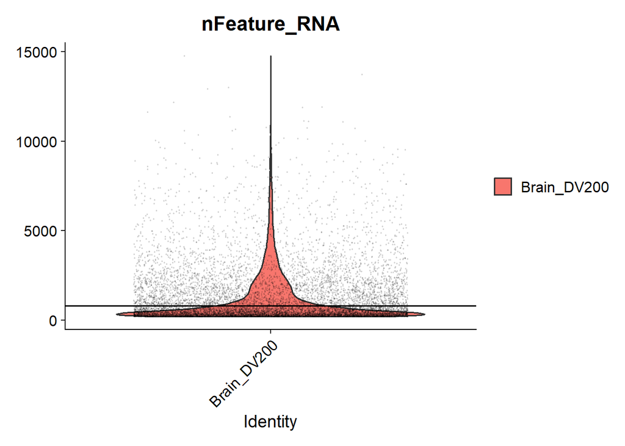

```r
# violin plot
VlnPlot(sobj, features= c("nFeature_RNA"), alpha = 0.1) + geom_hline(yintercept = 800)
```

The violin plot is good to visualise the number of genes per cell, we can see a high density of barcodes in the bottom of the plot (median ~600 genes) which correspond to debris, dead cells or empty droplets, so we keep cells with more than 800 genes.

We do not apply an upper threshold on the number of genes : some real cells have a lot of genes (e.g. inhibitory neurons have a median of ~5000 genes and ~11k UMI in this dataset), a hard cut at 5000 genes would remove them. Doublets/multiplets are removed later with scDblFinder.

```r
summary(sobj$nCount_RNA)
```

```
    Min.  1st Qu.   Median     Mean  3rd Qu.     Max.
   212.0    411.0    840.5   2893.9   2540.8 334112.0
```

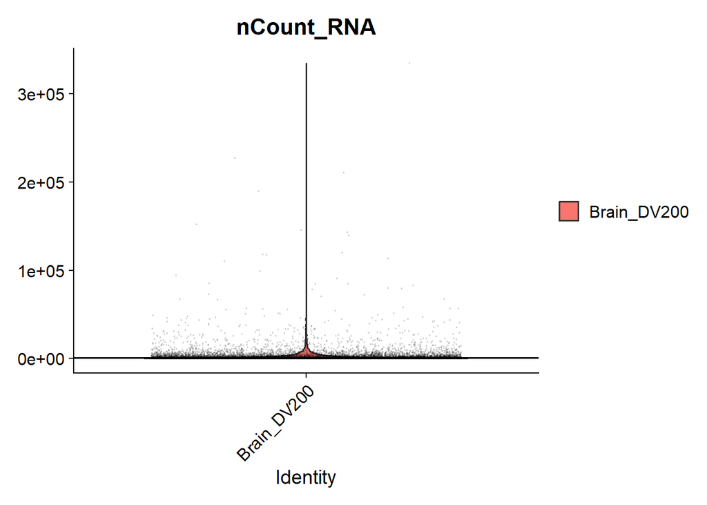

```r
#Violin plot (to see number of UMI (RNAs) per cell )
VlnPlot(sobj, features = c ("nCount_RNA"), alpha = 0.1) + geom_hline(yintercept = 1000)
```

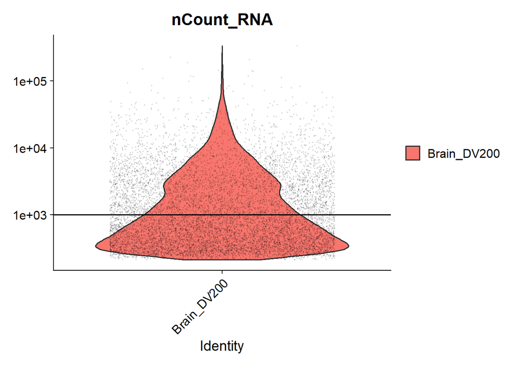

```r
#hard to visualise so lets log scale
VlnPlot(sobj, features = c ("nCount_RNA"),log=TRUE, alpha = 0.1) + geom_hline(yintercept = 1000)
```

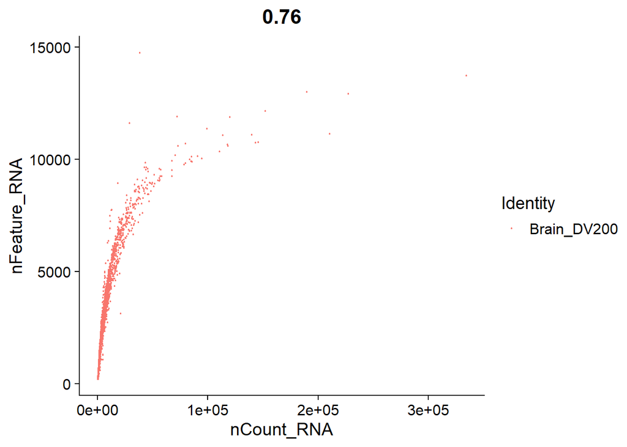

```r
FeatureScatter(sobj, feature1="nCount_RNA", feature2 = "nFeature_RNA", pt.size = 0.1)
```

Pearson correlation is 0.76 which is good, a minimum of 1000 UMI per cell removes the empty droplets and low quality cells.

```r
# lets define the thresholds based on Vlnplots
minGenes = 800
minUmi = 1000
```

```r
sobjFiltrd = subset(sobj, subset = nFeature_RNA > minGenes & nCount_RNA > minUmi)
```

ok now i’ve filtered the object on the thresholds defined, lets visualise before we clean the environment

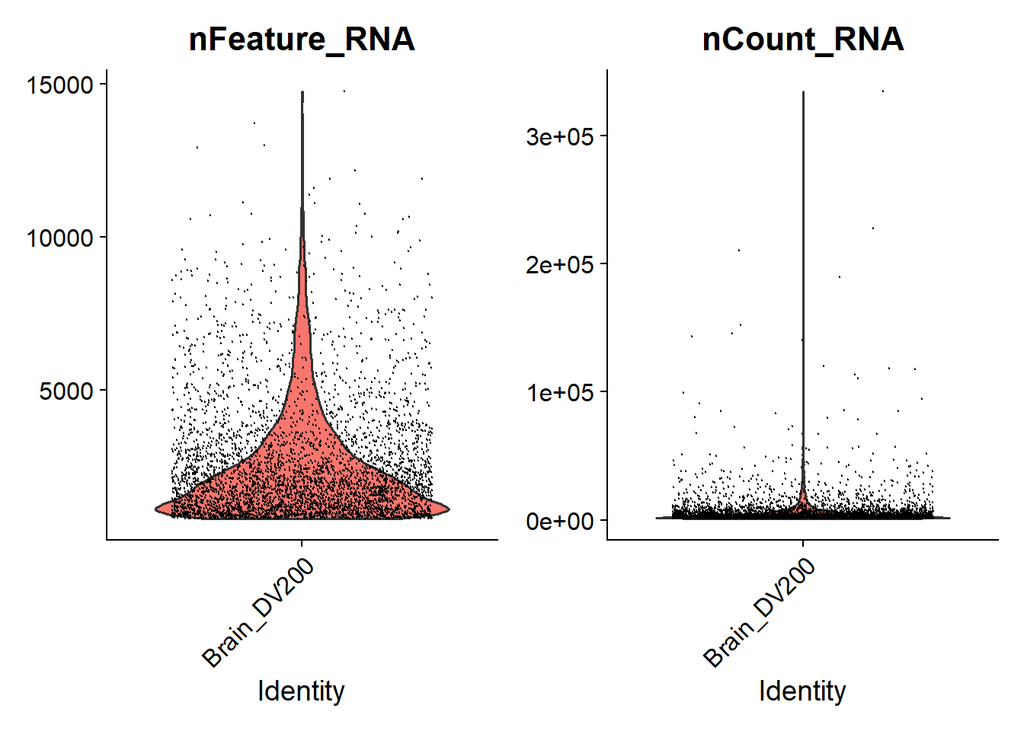

```r
VlnPlot(sobjFiltrd, features = c("nFeature_RNA", "nCount_RNA"), ncol = 2,pt.size = 0.01)
```

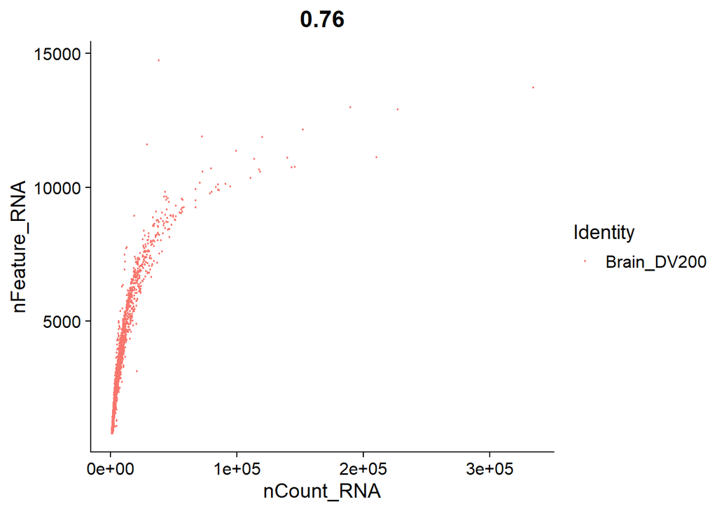

```r
FeatureScatter(sobjFiltrd, feature1 = "nCount_RNA", feature2 = "nFeature_RNA",pt.size =0.1)
```

ok good, now lets process mitochondrial genes.

```r
mito_pattern <- "^MT-"
sobjFiltrd$percent_mt<- PercentageFeatureSet(sobjFiltrd, pattern = mito_pattern)
summary(sobjFiltrd$percent_mt)
```

```
   Min. 1st Qu.  Median    Mean 3rd Qu.    Max.
 0.0000  0.3858  0.8743  1.9262  2.3927 37.4604
```

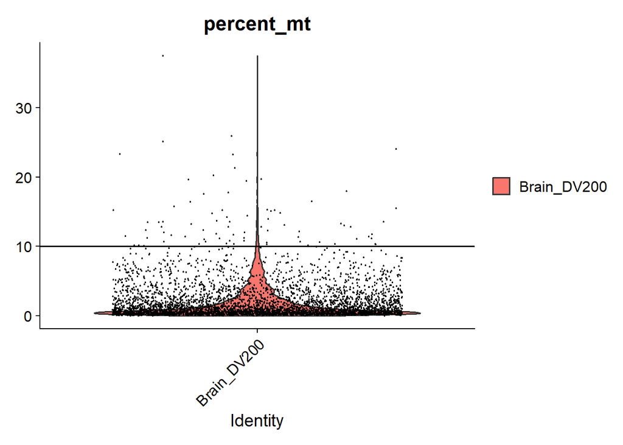

```r
#Violin plot mito genes
VlnPlot(sobjFiltrd, features = c("percent_mt")) + geom_hline(yintercept = 10)
```

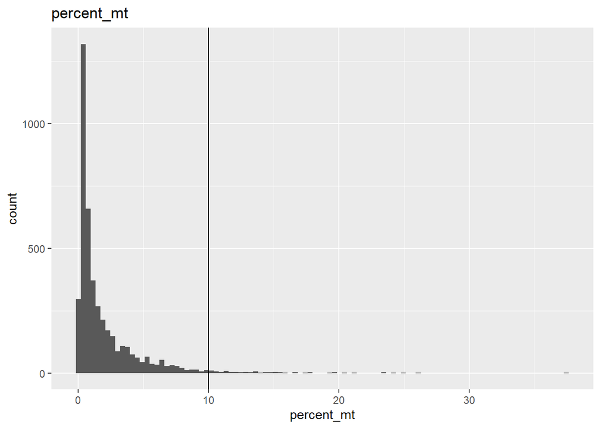

```r
#histogram
ggplot(data.frame(percent_mt = sobjFiltrd$percent_mt), aes(x = percent_mt)) +
  geom_histogram(bins = 100) + geom_vline(xintercept = 10) + ggtitle("percent_mt")
```

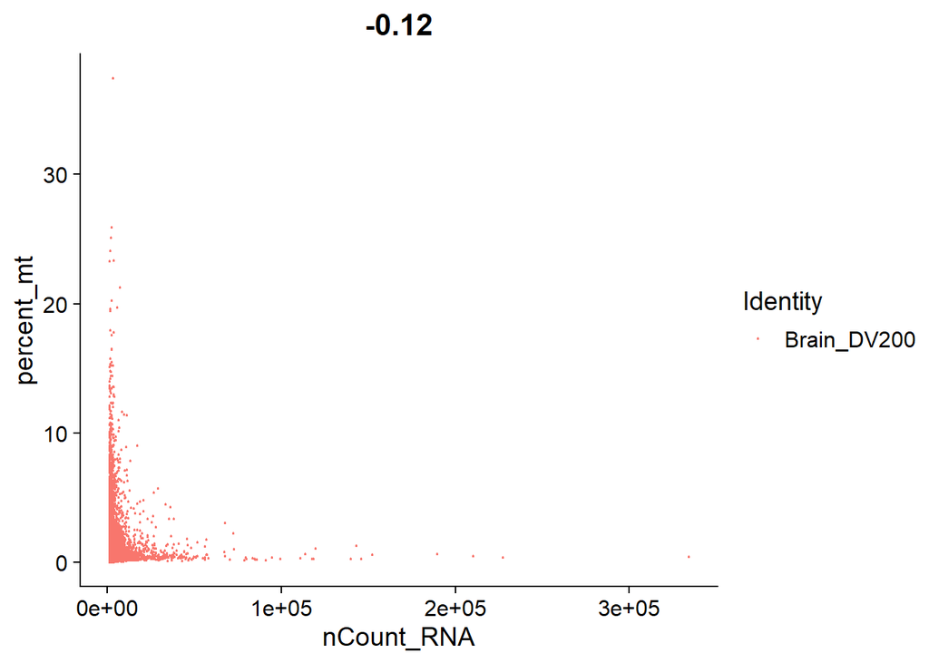

```r
FeatureScatter(sobjFiltrd, feature1 = "nCount_RNA", feature2 = "percent_mt",pt.size =0.1)
```

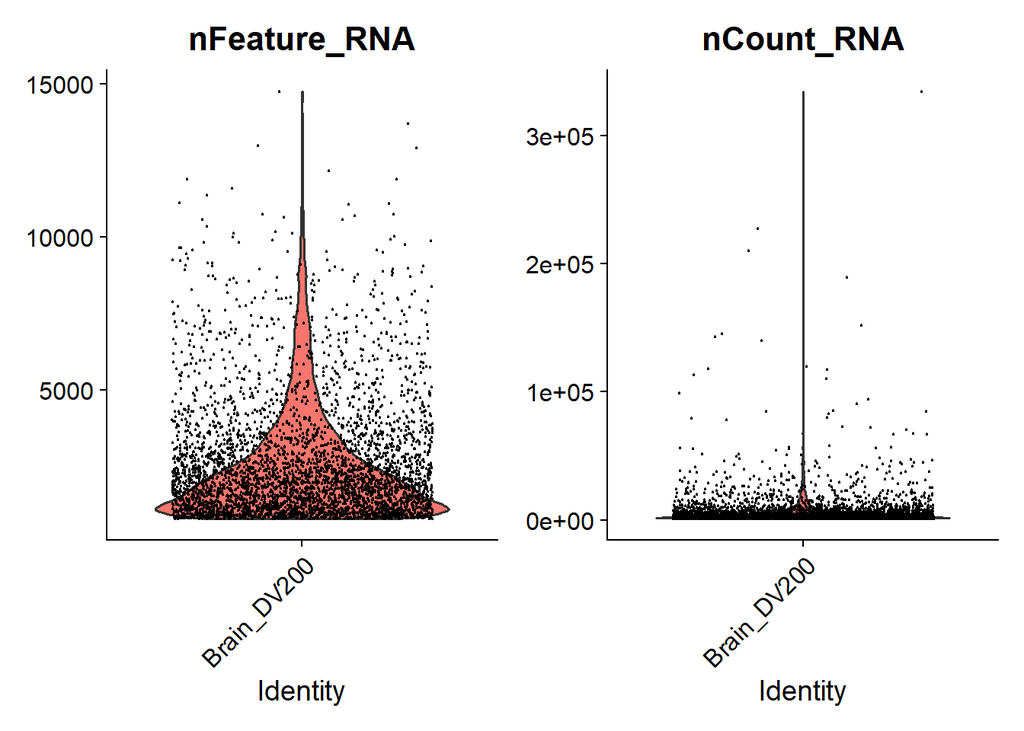

```r
maxpct_mt = 10
sobjFiltrd <- subset(sobjFiltrd, subset =  percent_mt < maxpct_mt)
VlnPlot(sobjFiltrd, features = c("nFeature_RNA", "nCount_RNA"), ncol = 2)
```

```r
ncol(sobjFiltrd) #Nbr of barcodes (cells)
```

```
[1] 4278
```

```r
nrow(sobjFiltrd) #Nbr of genes
```

```
[1] 18988
```

```r
rm(sobj)
gc()
```

```
           used  (Mb) gc trigger   (Mb)  max used   (Mb)
Ncells 11736924 626.9   19463582 1039.5  19463582 1039.5
Vcells 37512586 286.2  106145434  809.9 110471620  842.9
```

Now we will remove doublets and multiplets using scDblFinder package, for this we need to convert the seurat object into other format using function : asSingleCellExperiment

```r
# Transforming Seurat object
sceobj<-as.SingleCellExperiment(sobjFiltrd)

#We remove doublets
set.seed(the.seed)
doublet_res<-scDblFinder(sceobj)

#We save the results in the Seurat object
sobjFiltrd$doublets.class <-doublet_res$scDblFinder.class

# % of doublets
table(sobjFiltrd$doublets.class)
```

```
singlet doublet
   4005     273
```

```r
round(100 * prop.table(table(sobjFiltrd$doublets.class)), 1)
```

```
singlet doublet
   93.6     6.4
```

We have 6.4% of doublets which is not high, the dataset is clean.

now lets remove the doublets and visualise again

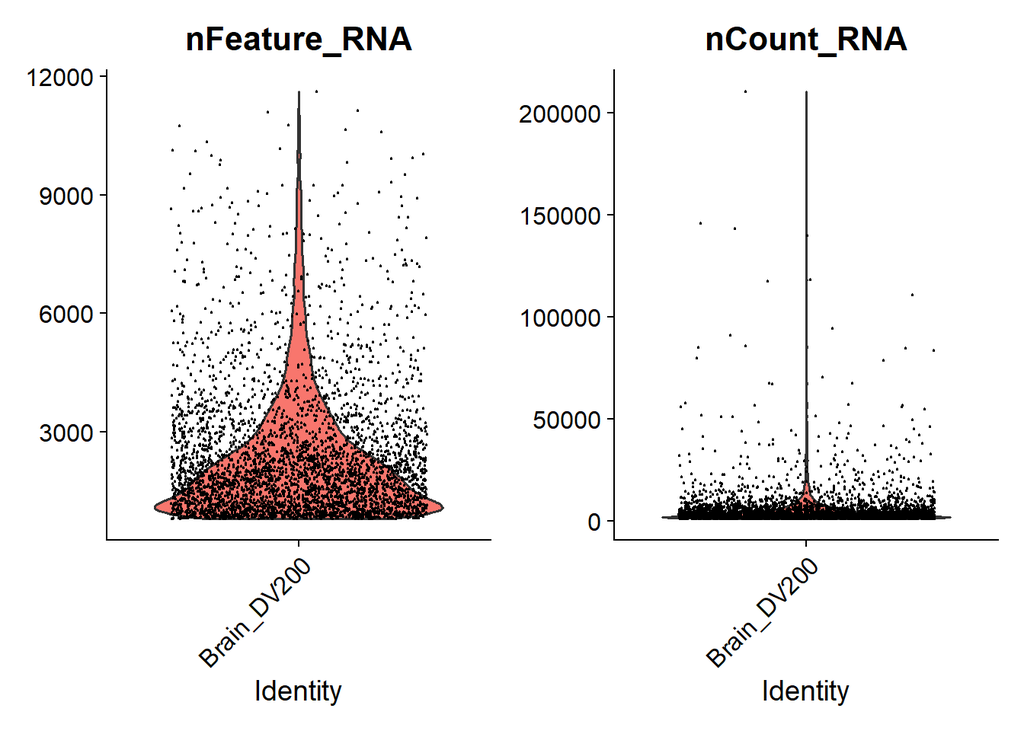

```r
sobjFiltrd <- subset(sobjFiltrd, subset = doublets.class == "singlet")
VlnPlot(sobjFiltrd, features = c("nFeature_RNA", "nCount_RNA"), ncol = 2)
```

```r
rm(doublet_res, sceobj)
gc()
```

```
           used  (Mb) gc trigger   (Mb)  max used   (Mb)
Ncells 11814286 631.0   19463582 1039.5  19463582 1039.5
Vcells 35463450 270.6  101963616  778.0 110471620  842.9
```

Now after filtering Mitochondrial genes and doublets/multiplets + low quality cells, we have to normalise the data, since some cells have high number of umi than others, some cells are more active than others due to their biology, but we also have sequencing bias that we need to correct by normalizing or via integration if needed

```r
sobjFiltrd <- NormalizeData(sobjFiltrd, normalization.method = "LogNormalize")
```

We can also perform SCTransform, but this method does require some computational ressources since it uses GLMs to adjust residus

now that we are done with QC step we go ahead and save

```r
# Save seurat object
save(sobjFiltrd, file = paste0('../data/processed_data/',sample.name,'_FILTERED.rda'))
```